# Ex08 Transformation

Samuel Hudec

27 novembra 2018

Vo financiách sa často vyskytuje *logaritmická transformácia* regresorov len z dôvodu interpretácie výsledkov. Takýto zásah do dát bez toho aby sa na dáta ktokoľvek pozrel je nepriatelný. **Z princípu, dáta majú prezratiť akú štruktúru má model mať.** Ibaže by sme použili veštiacu gulu. Vysvetlime si to, predpokladajme lineárny model:

$$y=X\beta+\epsilon \quad \rightarrow \quad y\sim N(X\beta, \sigma^2I)$$
Ztransformujem odozvu spojitou funkciou $h()$, potom máme model

$$h(y)=X\beta+\epsilon \quad \rightarrow \quad h(y)\sim ???$$
Pretransformovanie odozvy je hrubý zásah do celého modelu, mení aj význam parametrov.

Pri prediktoroch je to inak, dokonca nutná transformácia sa dá vyčítať aj z obrázka podľa oka, niekedy to voláme aj odmodelovanie. Žial nie vždy sa dajú vykresliť obrázky, hlavne ak máme “veľa” prediktorov. Na odhalenie nutnej transformácie nám slúžia rôzne nástroje ako napríklad **neparametrická regresia** o ktorej si bližšie povieme na druhom kurze. V cvičení použijeme aditívny model využívajúci spline, len ako “radiaci nástroj”.

- Aké “bezpečné” transformácie poznáte z prednážok?

## Transformácia odozvy

Na ukážku, vezmime slávne dáta `ozone` a pre jednoduchosť uvažujme regresory `O3`, `temp`, `humidity` a `ibh`. Najprv urobte, čo je potrebné pred každým lineárnym modelom, potom:

- Zobrazme si tieto premenné a interpretujte obrázok.
- Vedeli by ste odmodelovať dáta lineárnim modelom?

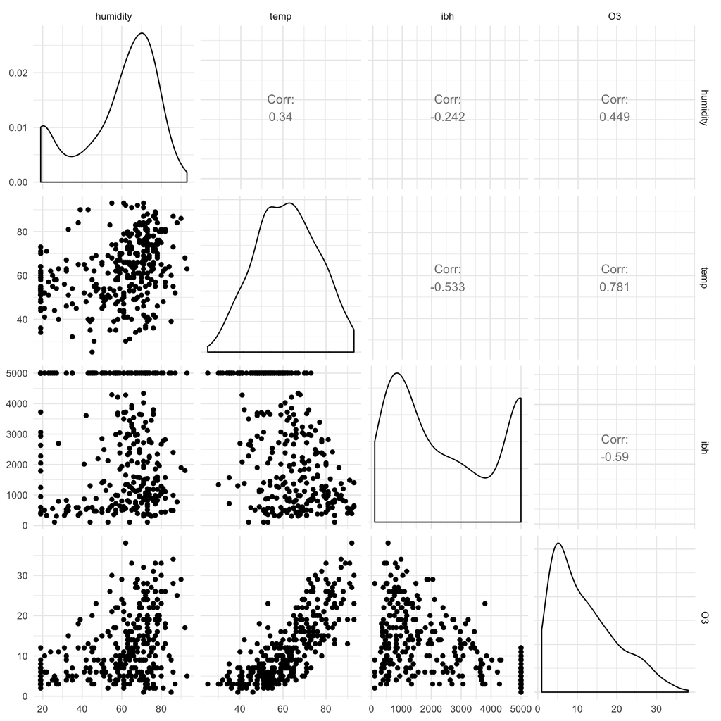

Odmodelujte dáta lineárnim modelom s `O3` ako odozvou.

```
##                Estimate  Std. Error t value  Pr(>|t|)
## (Intercept) -1.0494e+01  1.6165e+00 -6.4918 3.159e-10
## temp         3.2963e-01  2.1095e-02 15.6261 < 2.2e-16
## humidity     7.7377e-02  1.3394e-02  5.7771 1.775e-08
## ibh         -1.0044e-03  1.6386e-04 -6.1296 2.543e-09
##
## n = 330, p = 4, Residual SE = 4.52433, R-Squared = 0.68
```

- Majú prediktory intuitívne hodnoty?
- Sú prediktory signifikantné?
- Koľko variancie model vysvetluje?

Urobte diagnostiku tohto lineárneho modelu. Sústredte sa hlavne na obrázok **residuals vs. fitted**. Poriadne okomentujte tento obrázok. Rovnako postupujte aj pri ostatných diagnostických nástrojov.

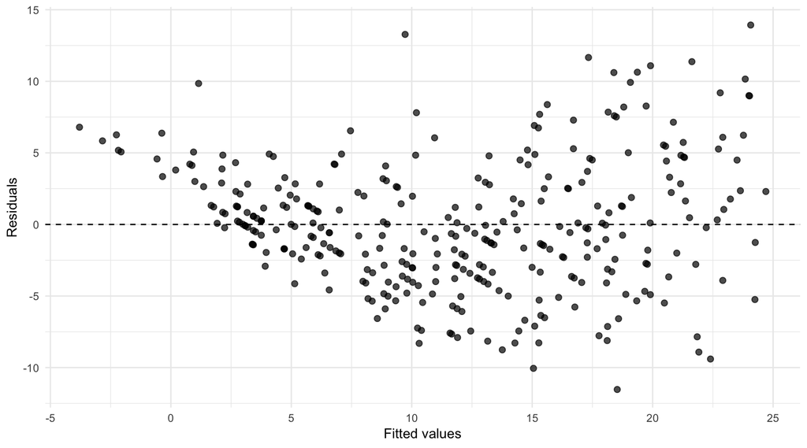

Ako by ste postupovali v takomto prípade, ak by ste mali použiť zatial vám známe nástroje?

### Box-Coxová transformácia odozvy

Odhadnúť z obrázku, ako transformovať odozvu je ťažké viac menej je to len **pokus a omyl**. Z tohoto dôvodu boli vymyslené rôzne nástroje. Naučme sa používať aspoň jeden. Použime boxcoxovú metodu `boxcox()` z knižnice `MASS` na odhadnutie transformácie odozvy nášho lineárneho modelu.

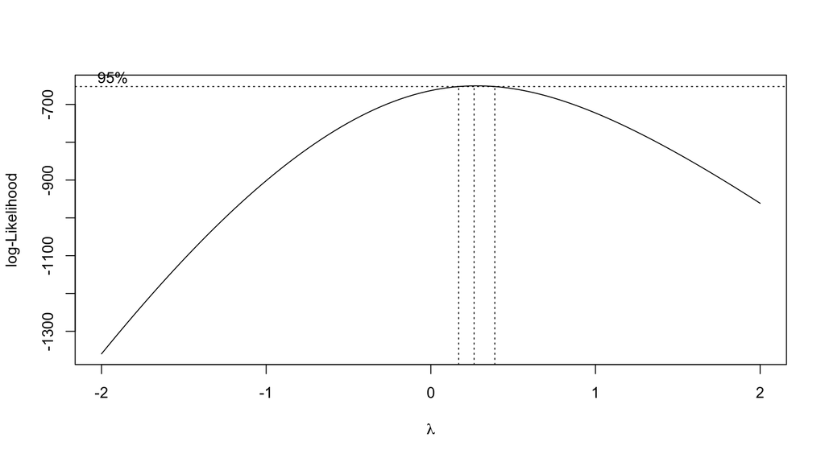

- Interpretujte obrázok.
- Čo by znamenalo, keby bol maximum likelihood okolo 1?

Použite radu z funkcie a transformujte odozvu.

```
##                Estimate  Std. Error t value  Pr(>|t|)
## (Intercept)  9.7115e-02  2.2001e-01  0.4414    0.6592
## temp         4.7221e-02  2.8711e-03 16.4471 < 2.2e-16
## humidity     1.1061e-02  1.8229e-03  6.0676  3.60e-09
## ibh         -1.6451e-04  2.2302e-05 -7.3762  1.36e-12
##
## n = 330, p = 4, Residual SE = 0.61578, R-Squared = 0.72
```

- Ako sa zmenili odhady parametrov?
- Ako sa zmenila ich signifikancia?
- Koľko percent variancie takýto model vysvetluje?

Urobte diagnostiku transformovaného modelu a vysvetlite na obrázku **residuals vs. fitted**.

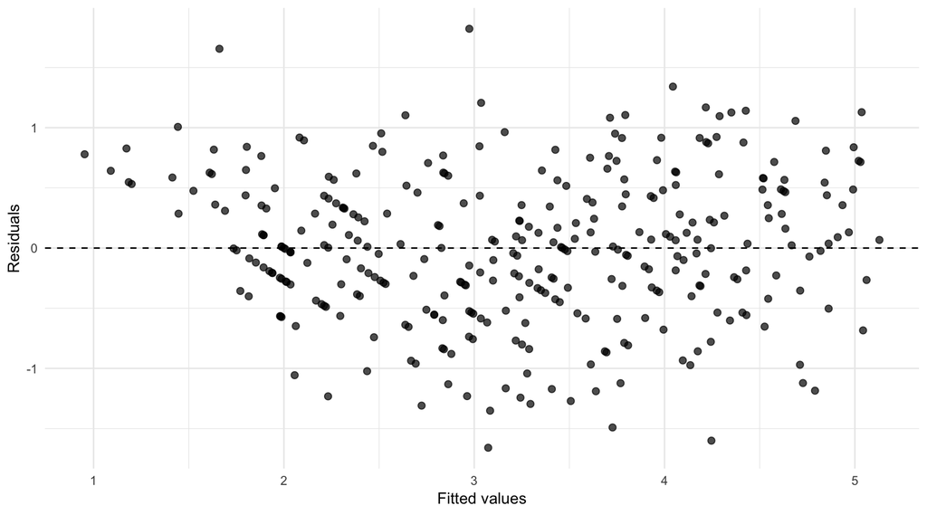

- Zmenili sa výstupy z diagnostických nástrojov?
- Aký vplyv mala transformácia odozvy na model?

## Transformácia (modelovanie) prediktorov

Vezmime si najjednoduchší prípad a uvažujme len `O3` ako odozvu a `temp` ako prediktor. Pozrime sa ako plýva teplota na ozón, najlepšie bude ak si to znázorníme na obrázku.

[figure not shown]

Ak sa nevieme rozhodnúť akú transformáciu použijeme, môžeme vyskušať nakresliť si cez dáta **splajn** jedena z možností neparametrickej regresie. Použijeme na to aditívny model `gam()` z knižnice `mgcv`. Sintax je rovnaký ako vo funkcii `lm()`, len na každý prediktor, ktorý chcete “vyhladiť” použijete funkciu `s()`. V našom jednoduchom prípade

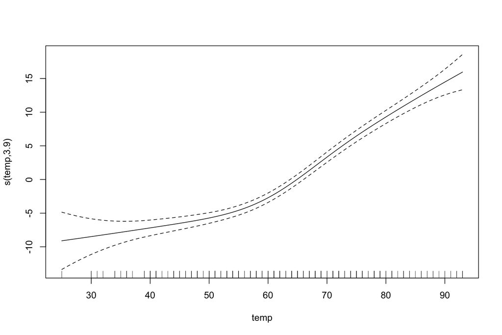

```r
mo_s=gam(O3~s(temp), data=ozone)
plot(mo_s)
```

- Čo nám radí model?

Aditívny model budeme používať len ako **poradcu** pri transformovaní, nebudeme sa venovať interpretácií výsledkov. Na odmodelovanie krivky v lineárnom modeli sa používa polynómom k-teho stupňa s funkciou `poly()` a bez nej.

```
##                 Estimate Std. Error t value  Pr(>|t|)
## (Intercept)     11.77576    0.26201 44.9443 < 2.2e-16
## poly(temp, 2)1 113.44503    4.75961 23.8350 < 2.2e-16
## poly(temp, 2)2  28.94506    4.75961  6.0814 3.324e-09
##
## n = 330, p = 3, Residual SE = 4.75961, R-Squared = 0.65
```

```
##               Estimate Std. Error t value  Pr(>|t|)
## (Intercept)  8.4264860  4.0105766  2.1011  0.036400
## temp        -0.3669889  0.1327230 -2.7651  0.006014
## I(temp^2)    0.0064675  0.0010635  6.0814 3.324e-09
##
## n = 330, p = 3, Residual SE = 4.75961, R-Squared = 0.65
```

- Prečo je rozdiel medzi odhadmi parametrov? (hint. `?poly`)

Interpretujte výstup a urobte diagnostiku modelu. Nakoniec zakreslite polynom do obrázka.

[figure not shown]

Teraz pritvrdme a uvažujeme model, ktorý bude obsahovať všetky prediktory z dát `ozone`. Použite aditívny model na poradenie vhodnej transformácie modelu.

```r
gam(O3~s(vh)+s(wind)+s(humidity)+s(temp)+s(ibh)+s(dpg)+s(ibt)+s(vis)+s(doy),data=ozone)
```

Bližšie sa porzime napríklad posledný prediktor `doy` a skontrolujme či nám aditívny model vhodne poradil podľa oka.

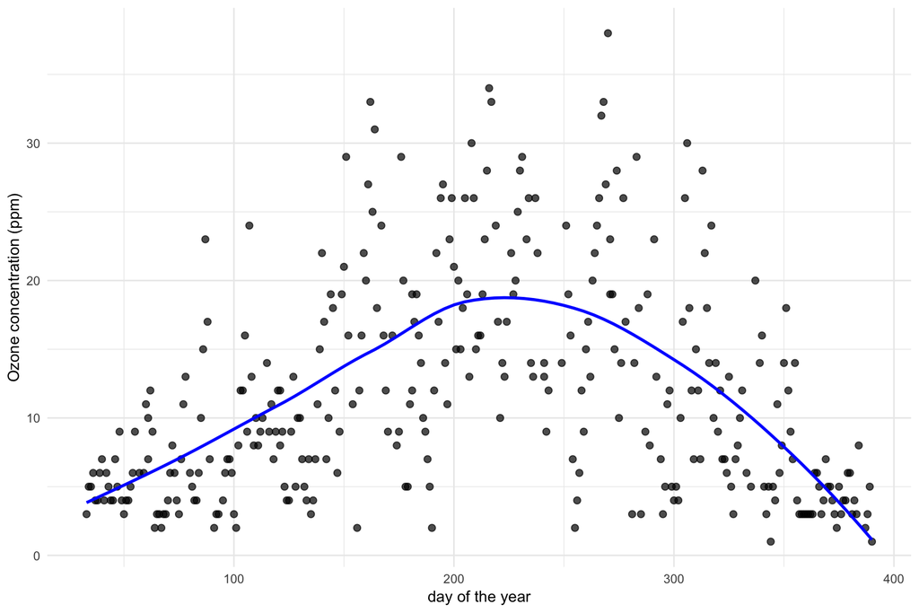

Zakomponujte všetky rady aditývneho modelu do lineárneho a potom urobte diagnostiku. * Pomohly sme si týmito transformáciami voči netransformovanému modelu?

## Samostatná práca

Vezmite dáta `aatemp` a urobte, čo je treba na začiatok. Fitnite plný regresný model s `temp` ako odozvou a `year` ako prediktorom.

1. Zakreslite fit do obrázka odozva a prediktora.
2. Vyskúšajte odmodelovať prediktor polynómom a otestujte ktorý je najlepší.
3. Zakreslite naljepší fit do rovnakého obrázka z 1. a vysvetlite prečo je lepší (alebo nie) ako ten lineárny.